# Final for Supervised Learning: Regression for Machine Learning

## Regression and Regularization with Housing for Ames, IA

#### 2020.12.01

## I. Objective

I am using the Ames, Iowa dataset from the class notes. This dataset contains 2930 observations and 82 variables related to house sales in Ames, Iowa. The variables are related to characteristics and measurements of the house, its location, and its purchase.

Refer to the [codebook](http://jse.amstat.org/v19n3/decock/DataDocumentation.txt) for a complete list of variables and labels.

I will fit four models to predict the *Sale Price* of the homes on the same training set. The models will be evaluated with the same test set. They will then be compared and analyzed and a final model will be chosen.

### 1. Packages

```python
import math
import numpy as np
import pandas as pd

from matplotlib import cm
import matplotlib.pyplot as plt
from matplotlib.ticker import FuncFormatter as FF
from matplotlib.ticker import StrMethodFormatter as SMF
import seaborn as sns

from sklearn.model_selection import cross_val_predict as CVP
from sklearn.model_selection import KFold

from sklearn.linear_model import Lasso
from sklearn.linear_model import LinearRegression as LR
from sklearn.linear_model import Ridge

from sklearn.metrics import mean_squared_error as MSErr
from sklearn.metrics import mean_absolute_error as MAErr
from sklearn.metrics import r2_score

from sklearn.model_selection import train_test_split as TTS
from sklearn.preprocessing import StandardScaler as SS
```

### 2. Load Data

```python
df = pd.read_csv('data/Ames_Housing_Data.tsv', sep = '\t')

#Set display options.
pd.options.display.max_rows = 100
pd.options.display.max_columns = 100
```

## II. Data Exploration

I am going to select a few variables that are noteworthy and compare relationships between them and to *Sale Price*. The variables are varied between numerical and categorical, so I plan to choose interesting variables that would be of common interest that also contain a minimal number of missing values.

### 1. Data types

```python
df.dtypes.value_counts()
```

```
object     43
int64      28
float64    11
dtype: int64
```

### 2. Dataframe descriptive stats

A summary of all variables is shown below.

```python
df.describe().round(2)
```

|  | Order | PID | MS SubClass | Lot Frontage | Lot Area | Overall Qual | Overall Cond | Year Built | Year Remod/Add | Mas Vnr Area | BsmtFin SF 1 | BsmtFin SF 2 | Bsmt Unf SF | Total Bsmt SF | 1st Flr SF | 2nd Flr SF | Low Qual Fin SF | Gr Liv Area | Bsmt Full Bath | Bsmt Half Bath | Full Bath | Half Bath | Bedroom AbvGr | Kitchen AbvGr | TotRms AbvGrd | Fireplaces | Garage Yr Blt | Garage Cars | Garage Area | … |
| --- | --- | --- | --- | --- | --- | --- | --- | --- | --- | --- | --- | --- | --- | --- | --- | --- | --- | --- | --- | --- | --- | --- | --- | --- | --- | --- | --- | --- | --- | --- |
| count | 2930.00 | 2.930000e+03 | 2930.00 | 2440.00 | 2930.00 | 2930.00 | 2930.00 | 2930.00 | 2930.00 | 2907.00 | 2929.00 | 2929.00 | 2929.00 | 2929.00 | 2930.00 | 2930.00 | 2930.00 | 2930.00 | 2928.00 | 2928.00 | 2930.00 | 2930.00 | 2930.00 | 2930.00 | 2930.00 | 2930.00 | 2771.00 | 2929.00 | 2929.00 | … |
| mean | 1465.50 | 7.144645e+08 | 57.39 | 69.22 | 10147.92 | 6.09 | 5.56 | 1971.36 | 1984.27 | 101.90 | 442.63 | 49.72 | 559.26 | 1051.61 | 1159.56 | 335.46 | 4.68 | 1499.69 | 0.43 | 0.06 | 1.57 | 0.38 | 2.85 | 1.04 | 6.44 | 0.60 | 1978.13 | 1.77 | 472.82 | … |
| std | 845.96 | 1.887308e+08 | 42.64 | 23.37 | 7880.02 | 1.41 | 1.11 | 30.25 | 20.86 | 179.11 | 455.59 | 169.17 | 439.49 | 440.62 | 391.89 | 428.40 | 46.31 | 505.51 | 0.52 | 0.25 | 0.55 | 0.50 | 0.83 | 0.21 | 1.57 | 0.65 | 25.53 | 0.76 | 215.05 | … |
| min | 1.00 | 5.263011e+08 | 20.00 | 21.00 | 1300.00 | 1.00 | 1.00 | 1872.00 | 1950.00 | 0.00 | 0.00 | 0.00 | 0.00 | 0.00 | 334.00 | 0.00 | 0.00 | 334.00 | 0.00 | 0.00 | 0.00 | 0.00 | 0.00 | 0.00 | 2.00 | 0.00 | 1895.00 | 0.00 | 0.00 | … |
| 25% | 733.25 | 5.284770e+08 | 20.00 | 58.00 | 7440.25 | 5.00 | 5.00 | 1954.00 | 1965.00 | 0.00 | 0.00 | 0.00 | 219.00 | 793.00 | 876.25 | 0.00 | 0.00 | 1126.00 | 0.00 | 0.00 | 1.00 | 0.00 | 2.00 | 1.00 | 5.00 | 0.00 | 1960.00 | 1.00 | 320.00 | … |
| 50% | 1465.50 | 5.354536e+08 | 50.00 | 68.00 | 9436.50 | 6.00 | 5.00 | 1973.00 | 1993.00 | 0.00 | 370.00 | 0.00 | 466.00 | 990.00 | 1084.00 | 0.00 | 0.00 | 1442.00 | 0.00 | 0.00 | 2.00 | 0.00 | 3.00 | 1.00 | 6.00 | 1.00 | 1979.00 | 2.00 | 480.00 | … |
| 75% | 2197.75 | 9.071811e+08 | 70.00 | 80.00 | 11555.25 | 7.00 | 6.00 | 2001.00 | 2004.00 | 164.00 | 734.00 | 0.00 | 802.00 | 1302.00 | 1384.00 | 703.75 | 0.00 | 1742.75 | 1.00 | 0.00 | 2.00 | 1.00 | 3.00 | 1.00 | 7.00 | 1.00 | 2002.00 | 2.00 | 576.00 | … |
| max | 2930.00 | 1.007100e+09 | 190.00 | 313.00 | 215245.00 | 10.00 | 9.00 | 2010.00 | 2010.00 | 1600.00 | 5644.00 | 1526.00 | 2336.00 | 6110.00 | 5095.00 | 2065.00 | 1064.00 | 5642.00 | 3.00 | 2.00 | 4.00 | 2.00 | 8.00 | 3.00 | 15.00 | 4.00 | 2207.00 | 5.00 | 1488.00 | … |

### 3. Missing values

A count of missing values by variable is shown below.

```python
df_na = df.isna().sum().to_frame().sort_values(by = 0, axis = 0)

df_na = df_na.rename(columns={0: 'NA Count'})

df_na.T
```

|  | Order | Sale Condition | Heating QC | Central Air | 1st Flr SF | 2nd Flr SF | Low Qual Fin SF | Gr Liv Area | Full Bath | Half Bath | Bedroom AbvGr | Kitchen AbvGr | Kitchen Qual | Foundation | TotRms AbvGrd | Fireplaces | Paved Drive | Wood Deck SF | Open Porch SF | Enclosed Porch | 3Ssn Porch | Screen Porch | Pool Area | Misc Val | Mo Sold | Yr Sold | Sale Type | Functional | Exter Cond | … |
| --- | --- | --- | --- | --- | --- | --- | --- | --- | --- | --- | --- | --- | --- | --- | --- | --- | --- | --- | --- | --- | --- | --- | --- | --- | --- | --- | --- | --- | --- | --- |
| NA Count | 0 | 0 | 0 | 0 | 0 | 0 | 0 | 0 | 0 | 0 | 0 | 0 | 0 | 0 | 0 | 0 | 0 | 0 | 0 | 0 | 0 | 0 | 0 | 0 | 0 | 0 | 0 | 0 | 0 | … |

Because there are plenty of variables without missing values, only complete columns will be used for the analysis.

```python
complete_columns = df_na[df_na['NA Count'] == 0].index.to_list()

df_no_na = df[complete_columns]
df_no_na.shape
```

```
(2930, 55)
```

### 4. Exploration 1

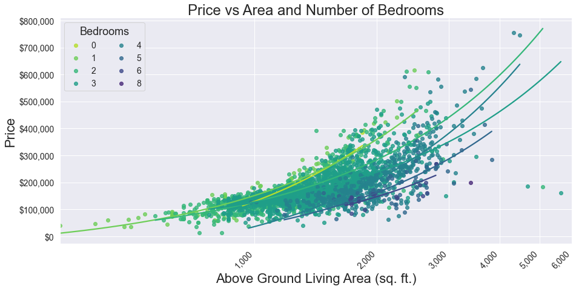

```python
sns.set()

#Scatter Plot.
exp1 = sns.lmplot(data = df_no_na, x = 'Gr Liv Area', y = 'SalePrice', hue = 'Bedroom AbvGr',
                  palette = 'viridis_r', ci = None, height = 6, aspect = 13 / 6)

#Axes.
ax = plt.gca()

#Title setup.
ax.set_title('Price vs Area and Number of Bedrooms', fontsize = 24)

#X-axis setup.
ax.set_xlabel("Above Ground Living Area (sq. ft.)", fontsize = 22)
ax.set_xscale('log')
xlabels = [1000, 2000, 3000, 4000, 5000, 6000]
ax.set_xticks(xlabels)
ax.set_xticklabels(xlabels, rotation = 45, ha = 'right')
ax.get_xaxis().set_major_formatter(FF(lambda x, p: format(int(x), ',')))

#Y-axis setup.
ax.set_ylabel("Price", fontsize = 22)
ax.yaxis.set_major_formatter(SMF('${x:,.0f}'))

ax.tick_params(axis = 'both', which = 'major', labelsize = 14)

#Legend setup.
exp1._legend.remove()
ax.legend(loc = 'upper left', title = 'Bedrooms', ncol = 2, title_fontsize = 18, fontsize = 14);
```

For the first exploration, *Price* is compared to *Above Ground Living Area* and *Number of Bedrooms*. *Area* had some right skew, so the x-axis was log scaled.

*Bedrooms* alone does not indicate a clear relationship with price. However, *Bedrooms* increases as the *Area* does. All regression lines for *Bedrooms* from $0$ to $6$ show a positive correlation of *Area* with *Price*. As noted below, there is only one house with $8$ bedrooms.

```python
bdrm_cnt = df_no_na['Bedroom AbvGr'].value_counts().sort_index().to_frame().rename(columns = {'Bedroom AbvGr': "Count of Houses"})
bdrm_cnt.index.name = "Number of Bedrooms"
bdrm_cnt.T
```

| Number of Bedrooms | 0 | 1 | 2 | 3 | 4 | 5 | 6 | 8 |
| --- | --- | --- | --- | --- | --- | --- | --- | --- |
| Count of Houses | 8 | 112 | 743 | 1597 | 400 | 48 | 21 | 1 |

### 5. Exploration 2

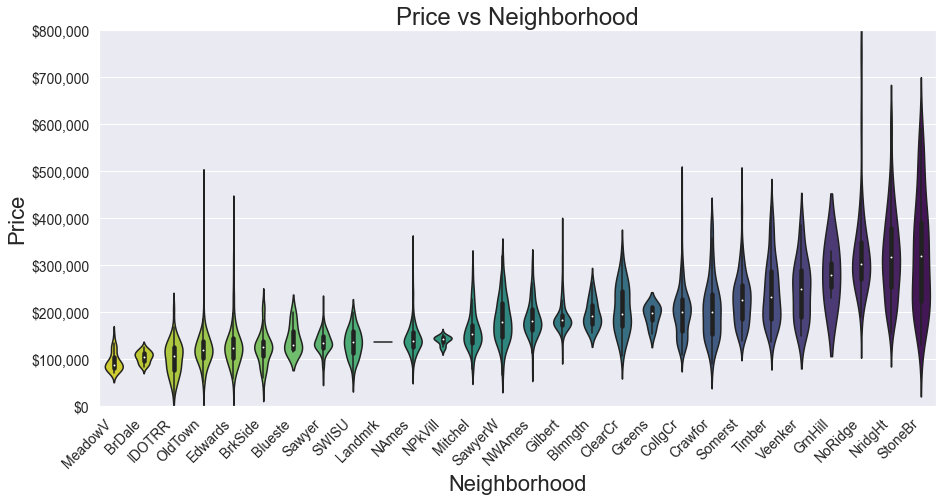

```python
#Sort Neighborhoods by median Price in ascending order.
xlabels = df_no_na.groupby(['Neighborhood'])['SalePrice'].median().sort_values().index

exp2 = sns.violinplot(data = df_no_na, x = 'Neighborhood', y = 'SalePrice', scale = 'width', width = 0.6,
                      palette = 'viridis_r', order = xlabels)

plt.gcf().set_size_inches(15, 6.92)

#Axes.
ax = plt.gca()

#Title setup.
ax.set_title('Price vs Neighborhood', fontsize = 24)

#X-axis setup.
ax.set_xlabel("Neighborhood", fontsize = 22)
ax.set_xticklabels(ax.get_xticklabels(), rotation = 45, ha = 'right')

#Y-axis setup.
ax.set_ylabel("Price", fontsize = 22)
ax.set_ylim(0, 800000)
ax.yaxis.set_major_formatter(SMF('${x:,.0f}'))

ax.tick_params(axis = 'both', which = 'major', labelsize = 14)
```

For the second exploration, *Price* is compared to *Neighborhood*. *Neighborhood* is represented by violin plots, sort in ascending order by median *Price*.

There is much overlap in *Price*, as there is significant and varying spread of house values within each *Neighborhood*. Overall there seems to be some correlation that warrants a further investigation. See frequency table of *Neighborhood* below.

```python
nbhd_cnt = df_no_na['Neighborhood'].value_counts().sort_index().to_frame().rename(columns = {'Neighborhood': "Count of Houses"})
nbhd_cnt.index.name = "Neighborhood"
nbhd_cnt.T
```

| Neighborhood | Blmngtn | Blueste | BrDale | BrkSide | ClearCr | CollgCr | Crawfor | Edwards | Gilbert | Greens | GrnHill | IDOTRR | Landmrk | MeadowV | Mitchel | NAmes | NPkVill | NWAmes | NoRidge | NridgHt | OldTown | SWISU | Sawyer | SawyerW | Somerst | StoneBr | Timber | Veenker |
| --- | --- | --- | --- | --- | --- | --- | --- | --- | --- | --- | --- | --- | --- | --- | --- | --- | --- | --- | --- | --- | --- | --- | --- | --- | --- | --- | --- | --- |
| Count of Houses | 28 | 10 | 30 | 108 | 44 | 267 | 103 | 194 | 165 | 8 | 2 | 93 | 1 | 37 | 114 | 443 | 23 | 131 | 71 | 166 | 239 | 48 | 151 | 125 | 182 | 51 | 72 | 24 |

### 6. Exploration 3

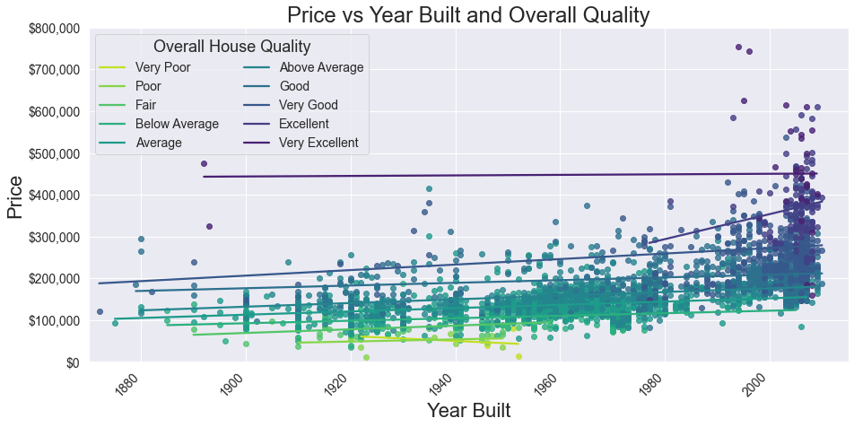

```python
#Scatter Plot.
exp3 = sns.lmplot(data = df_no_na, x = 'Year Built', y = 'SalePrice', hue = 'Overall Qual',
                  palette = 'viridis_r', ci = None, height = 6, aspect = 13 / 6)

#Axes.
ax = plt.gca()

#Title setup.
ax.set_title('Price vs Year Built and Overall Quality', fontsize = 24)

#X-axis setup.
ax.set_xlabel("Year Built", fontsize = 22)
ax.set_xlim(1870, 2015)
ax.set_xticklabels(ax.get_xticklabels(), rotation = 45, ha = 'right')

#Y-axis setup.
ax.set_ylabel("Price", fontsize = 22)
ax.set_ylim(0, 800000)
ax.yaxis.set_major_formatter(SMF('${x:,.0f}'))

ax.tick_params(axis = 'both', which = 'major', labelsize = 14)

#Legend setup.
exp3._legend.remove()
ax.legend(loc = 'upper left', title = 'Overall House Quality',
          labels = ['Very Poor', 'Poor', 'Fair', 'Below Average', 'Average',
                    'Above Average', 'Good', 'Very Good', 'Excellent', 'Very Excellent'],
          ncol = 2, title_fontsize = 18, fontsize = 14);
```

For the third exploration, *Price* is compared to *Year Built* and *Overall Quality*.

Comparing these three together is quite telling. Houses built earlier are of overall lower quality and lower selling price, as seen with the yellow, green, and cyan data points in the bottom of the graph. From 1990 - 2010, there is a sharp increase in quality and selling price, as seen with the blue, indigo, and purple data points on the far right of the graph.

The regression lines for *Overall Quality* show a positive relationship for *Year Built* and *Sale Price*. Furthurmore, there is very little intersection of these lines, they are clearly separated. The exception is 'Very Poor' and 'Poor' at the bottom center of the graph.

### 7. Target Variable

A histogram of *Sale Price* is shown below.

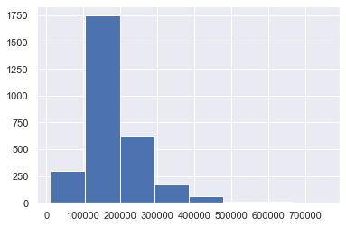

```python
df_no_na['SalePrice'].hist(bins = 8);
```

*Sale Price* is log transformed to have a more normal distribution.

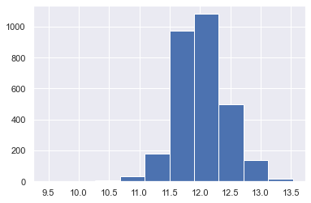

```python
np.log1p(df_no_na['SalePrice']).hist();
```

*Sale Price* is set as the index.

In addition, *Order* and *PID* are dropped, as they are ID variables.

```python
df_final = df_no_na.drop(['Order', 'PID'], axis = 1)
df_final['SalePrice'] = np.log1p(df_no_na['SalePrice'])
df_final.set_index('SalePrice', inplace = True)
```

### 8. One-hot encoding for dummy variables

Catgorical variables are encoded.

```python
#Code from class notebook.
one_hot_encode_cols = df_final.dtypes[df_final.dtypes == np.object]
one_hot_encode_cols = one_hot_encode_cols.index.tolist()

df_final = pd.get_dummies(df_final, columns = one_hot_encode_cols, drop_first=True)
df_final.shape
```

```
(2930, 191)
```

### 9. Log transforming skew variables

Check for skewed distributions.

```python
#Code from class notebook.
float_cols = df_final.columns[df_final.dtypes == np.float]

skew_limit = 0.75
skew_vals = df_final[float_cols].skew()
skew_cols = (skew_vals
             .sort_values(ascending = False)
             .to_frame()
             .rename(columns = {0: 'Skew'})
             .query('abs(Skew) > {}'.format(skew_limit)))

skew_cols
```

|  | Skew |
| --- | --- |

```python
df_final.head()
```

| SalePrice | 1st Flr SF | 2nd Flr SF | Low Qual Fin SF | Gr Liv Area | Full Bath | Half Bath | Bedroom AbvGr | Kitchen AbvGr | TotRms AbvGrd | Fireplaces | Wood Deck SF | Open Porch SF | Enclosed Porch | 3Ssn Porch | Screen Porch | Pool Area | Misc Val | Mo Sold | Yr Sold | Lot Area | MS SubClass | Overall Qual | Overall Cond | Year Built | Year Remod/Add | Sale Condition_AdjLand | Sale Condition_Alloca | Sale Condition_Family | Sale Condition_Normal | … |
| --- | --- | --- | --- | --- | --- | --- | --- | --- | --- | --- | --- | --- | --- | --- | --- | --- | --- | --- | --- | --- | --- | --- | --- | --- | --- | --- | --- | --- | --- | --- |
| 12.278398 | 1656 | 0 | 0 | 1656 | 1 | 0 | 3 | 1 | 7 | 2 | 210 | 62 | 0 | 0 | 0 | 0 | 0 | 5 | 2010 | 31770 | 20 | 6 | 5 | 1960 | 1960 | 0 | 0 | 0 | 1 | … |
| 11.561725 | 896 | 0 | 0 | 896 | 1 | 0 | 2 | 1 | 5 | 0 | 140 | 0 | 0 | 0 | 120 | 0 | 0 | 6 | 2010 | 11622 | 20 | 5 | 6 | 1961 | 1961 | 0 | 0 | 0 | 1 | … |
| 12.055256 | 1329 | 0 | 0 | 1329 | 1 | 1 | 3 | 1 | 6 | 0 | 393 | 36 | 0 | 0 | 0 | 0 | 12500 | 6 | 2010 | 14267 | 20 | 6 | 6 | 1958 | 1958 | 0 | 0 | 0 | 1 | … |
| 12.404928 | 2110 | 0 | 0 | 2110 | 2 | 1 | 3 | 1 | 8 | 2 | 0 | 0 | 0 | 0 | 0 | 0 | 0 | 4 | 2010 | 11160 | 20 | 7 | 5 | 1968 | 1968 | 0 | 0 | 0 | 1 | … |
| 12.154258 | 928 | 701 | 0 | 1629 | 2 | 1 | 3 | 1 | 6 | 1 | 212 | 34 | 0 | 0 | 0 | 0 | 0 | 3 | 2010 | 13830 | 60 | 5 | 5 | 1997 | 1998 | 0 | 0 | 0 | 1 | … |

5 rows × 191 columns

### 10. Train and Test Split.

Data is ready for modeling.

```python
X = df_final.reset_index().drop('SalePrice', axis = 1)
y = df_final.index

X_train, X_test, y_train, y_test = TTS(X, y, test_size = 0.3, random_state = 13131)
```

## III. Modeling

### 1. Linear Regression

All variables will be used as predictors.

```python
X_train_1 = X_train.copy()
X_test_1 = X_test.copy()

reg_1 = LR().fit(X_train_1, y_train)
y_pred = reg_1.predict(X_test_1)
```

### 2. Manual Variable Selection

Based on common conversations I've heard and read about purchasing a home in the past 30 years, I chose the following variables as predictors of *Sale Price*.

- *First Floor Area* and *Second Floor Area*
- *Bedrooms*
- *Full Bathrooms* and *Half Bathrooms*
- *Neighborhood* (its corresponding categories)
- *Overall Condition* and *Overall Quality* (their corresponding categories)
- *Year Built*

I think these will give a good snapshot and I am curious to see if they show up as final predictors, as well as how the overall manual model compares with the calculated models.

```python
#Numerical predictors.
predictors2 = ['1st Flr SF', '2nd Flr SF', 'Bedroom AbvGr', 'Full Bath',
               'Half Bath', 'Overall Cond', 'Overall Qual', 'Year Built']

#Neighborhoods has been one hot encoded.
neighborhoods = [v for v in df_final.columns.to_list() if v.startswith('Neighborhood')]

X_train_2 = X_train[predictors2 + neighborhoods]
X_test_2 = X_test[predictors2 + neighborhoods]

reg_2 = LR().fit(X_train_2, y_train)
```

### 3. Regularized Regression Setup

#### K Fold

```python
kf = KFold(shuffle = True, random_state = 13131, n_splits = 3)
```

#### Optimization Function

```python
#Retrieve R2 scores for different alpha for LASSO or Ridge.
def optimize_alpha(alphas, x, y, model, kf):

    #Scale and transform x.
    s = SS()
    x = s.fit_transform(x)

    #List of R2.
    r2_scores = []

    for alpha in alphas:

        reg = model(alpha = alpha, max_iter = 500000)
        y_pred = CVP(reg, x, y, cv = kf)
        score = r2_score(y, y_pred)
        r2_scores.append(score)

    return(r2_scores)
```

#### Graph Helper

```python
def alpha_r2_graph(alphas, R2s, xlabels, model):

    df = pd.DataFrame(data = {'alpha': alphas,
                              'R2': R2s})
    sns.set()

    #Scatter Plot.
    sns.lineplot(data = df,
                 x = 'alpha',
                 y = 'R2',
                 marker = 'o')

    #Size.
    plt.gcf().set_size_inches(15, 6.92)
    paper_rc = {'lines.linewidth': 2, 'lines.markersize': 6}

    #Axes.
    ax = plt.gca()

    #Title setup.
    ax.set_title("Optimizing Hyperparameter for {} Regression".format(model), fontsize = 24)

    #X-axis setup.
    ax.set_xlabel("α", fontsize = 22)
    ax.set_xscale('log')
    ax.set_xticks(xlabels)
    ax.set_xticklabels(xlabels, rotation = 45, ha = 'right')
    if (model == 'Ridge') :
        ax.get_xaxis().set_major_formatter(FF(lambda x, p: format(int(x), ',')))

    #Y-axis setup.
    ax.set_ylabel("R2", fontsize = 22)
    ylabels = [0, 0.2, 0.4, 0.6, 0.8, 1]
    ax.set_xticks(xlabels)

    ax.tick_params(axis = 'both', which = 'major', labelsize = 14)
```

### 4. LASSO

All variables will be used as predictors with an $L_1$ regularization.

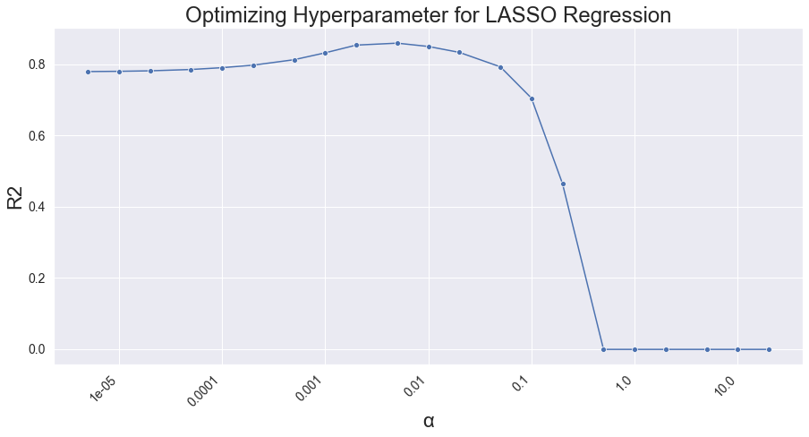

```python
alphas = list(pd.core.common.flatten([[a / 2, a, 2 * a] for a in np.geomspace(1e-5, 1e1, 7)]))
xlabels = [a for a in np.geomspace(1e-5, 1e1, 7)]

s = SS()
X_train_3 = s.fit_transform(X_train)

#Determine R2s and graph.
r2s_l = optimize_alpha(alphas, X_train_3, y_train, Lasso, kf)
alpha_r2_graph(alphas, r2s_l, xlabels, 'LASSO')
```

$α = 0.005$ is optimal.

```python
X_test_3 = s.transform(X_test)

reg_3 = Lasso(alpha = 0.005).fit(X_train_3, y_train)
```

### 5. Ridge

All variables will be used as predictors with an $L_2$ regularization.

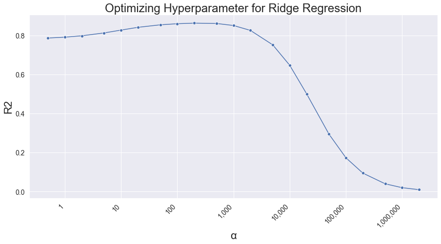

```python
alphas = list(pd.core.common.flatten([[a / 2, a, 2 * a] for a in np.geomspace(1, 1e6, 7)]))
xlabels = [a for a in np.geomspace(1, 1e6, 7)]

s = SS()
X_train_4 = s.fit_transform(X_train)

#Determine R2s and graph.
r2s_r = optimize_alpha(alphas, X_train_4, y_train, Ridge, kf)
alpha_r2_graph(alphas, r2s_r, xlabels, 'Ridge')
```

$α = 200$ is optimal.

```python
X_test_4 = s.transform(X_test)

reg_4 = Ridge(alpha = 200).fit(X_train_4, y_train)
```

## IV. Evaluation and Selection

### 1. Helper Function

```python
#Inputs regression models, predictors, and y-values, outputs DataFrame of R2, Adjusted R2, RMSE, and MAE.
def summary_df(models, Xs, Y) :

    index = ['All Variables', 'My Variables', 'LASSO', 'Ridge']
    R2 = []
    ADJ_R2 = []
    RMSE = []
    MAE = []

    for i in range(4):
        y_pred = models[i].predict(Xs[i])

        #R2.
        r2 = r2_score(Y, y_pred)
        R2.append(r2)

        #Adj R2.
        adj_r2 = 1.0 - (1.0 - r2) * (len(Y) - 1.0) / (len(Y) - Xs[i].shape[1] - 1.0)
        ADJ_R2.append(adj_r2)

        #RMSE.
        rmse = math.sqrt(MSErr(Y, y_pred))
        RMSE.append(rmse)

        #MAE.
        mae = MAErr(Y, y_pred)
        MAE.append(mae)

    df = pd.DataFrame(data = {'R2': R2,
                              'Adjusted R2': ADJ_R2,
                              'RMSE': RMSE,
                              'MAE': MAE},
                      index = index)
    return(df)
```

### 2. Train Data

```python
models = [reg_1, reg_2, reg_3, reg_4]
X_trains = [X_train_1, X_train_2, X_train_3, X_train_4]

summary_df(models, X_trains, y_train)
```

|  | R2 | Adjusted R2 | RMSE | MAE |
| --- | --- | --- | --- | --- |
| All Variables | 0.923746 | 0.915911 | 0.115140 | 0.080549 |
| My Variables | 0.857730 | 0.855258 | 0.157272 | 0.106099 |
| LASSO | 0.897472 | 0.886938 | 0.133510 | 0.091102 |
| Ridge | 0.912745 | 0.903780 | 0.123166 | 0.084782 |

### 3. Test Data

```python
X_tests = [X_test_1, X_test_2, X_test_3, X_test_4]

summary_df(models, X_tests, y_test)
```

|  | R2 | Adjusted R2 | RMSE | MAE |
| --- | --- | --- | --- | --- |
| All Variables | 0.827449 | 0.779476 | 0.159716 | 0.094183 |
| My Variables | 0.861722 | 0.855981 | 0.142977 | 0.100758 |
| LASSO | 0.882675 | 0.850057 | 0.131700 | 0.092853 |
| Ridge | 0.879854 | 0.846450 | 0.133274 | 0.093467 |

### 4. Summary of Metrics

Including **All Variables** was clearly best for the training data, but clearly overfit and the worst for the test data. It will be ignored from here on.

#### My Variable Predictors

```python
X_train_2.columns
```

```
Index(['1st Flr SF', '2nd Flr SF', 'Bedroom AbvGr', 'Full Bath', 'Half Bath',
       'Overall Cond', 'Overall Qual', 'Year Built', 'Neighborhood_Blueste',
       'Neighborhood_BrDale', 'Neighborhood_BrkSide', 'Neighborhood_ClearCr',
       'Neighborhood_CollgCr', 'Neighborhood_Crawfor', 'Neighborhood_Edwards',
       'Neighborhood_Gilbert', 'Neighborhood_Greens', 'Neighborhood_GrnHill',
       'Neighborhood_IDOTRR', 'Neighborhood_Landmrk', 'Neighborhood_MeadowV',
       'Neighborhood_Mitchel', 'Neighborhood_NAmes', 'Neighborhood_NPkVill',
       'Neighborhood_NWAmes', 'Neighborhood_NoRidge', 'Neighborhood_NridgHt',
       'Neighborhood_OldTown', 'Neighborhood_SWISU', 'Neighborhood_Sawyer',
       'Neighborhood_SawyerW', 'Neighborhood_Somerst', 'Neighborhood_StoneBr',
       'Neighborhood_Timber', 'Neighborhood_Veenker'],
      dtype='object')
```

#### LASSO Predictors

```python
X_train.columns[reg_3.coef_ != 0]
```

```
Index(['1st Flr SF', 'Gr Liv Area', 'Full Bath', 'Kitchen AbvGr', 'Fireplaces',
       'Wood Deck SF', 'Open Porch SF', 'Screen Porch', 'Pool Area',
       'Misc Val', 'Yr Sold', 'Lot Area', 'MS SubClass', 'Overall Qual',
       'Overall Cond', 'Year Built', 'Year Remod/Add', 'Sale Condition_Normal',
       'Sale Condition_Partial', 'Heating QC_Po', 'Heating QC_TA',
       'Central Air_Y', 'Kitchen Qual_Fa', 'Kitchen Qual_TA',
       'Foundation_PConc', 'Foundation_Slab', 'Paved Drive_Y', 'Sale Type_Con',
       'Sale Type_New', 'Sale Type_Oth', 'Functional_Maj2', 'Functional_Sal',
       'Functional_Sev', 'Functional_Typ', 'Exter Cond_Fa', 'Exter Cond_Po',
       'Heating_GasW', 'Heating_Grav', 'Condition 1_Feedr', 'Condition 1_Norm',
       'Condition 1_PosN', 'House Style_2.5Fin', 'House Style_SFoyer',
       'Bldg Type_2fmCon', 'Bldg Type_Twnhs', 'Bldg Type_TwnhsE',
       'Condition 2_PosA', 'Condition 2_RRAe', 'Exter Qual_TA',
       'Neighborhood_BrDale', 'Neighborhood_ClearCr', 'Neighborhood_Crawfor',
       'Neighborhood_Edwards', 'Neighborhood_Gilbert', 'Neighborhood_GrnHill',
       'Neighborhood_MeadowV', 'Neighborhood_NoRidge', 'Neighborhood_NridgHt',
       'Neighborhood_OldTown', 'Neighborhood_SawyerW', 'Neighborhood_Somerst',
       'Neighborhood_StoneBr', 'Neighborhood_Timber', 'Land Slope_Mod',
       'Lot Config_CulDSac', 'Utilities_NoSeWa', 'Utilities_NoSewr',
       'Land Contour_HLS', 'Lot Shape_IR3', 'MS Zoning_C (all)',
       'MS Zoning_RL', 'MS Zoning_RM', 'Roof Style_Hip',
       'Exterior 1st_BrkComm', 'Exterior 1st_BrkFace', 'Exterior 1st_Stucco',
       'Exterior 2nd_CmentBd', 'Exterior 2nd_Stucco'],
      dtype='object')
```

#### Ridge Predictors

```python
X_train.columns[reg_4.coef_ != 0]
```

```
Index(['1st Flr SF', '2nd Flr SF', 'Low Qual Fin SF', 'Gr Liv Area',
       'Full Bath', 'Half Bath', 'Bedroom AbvGr', 'Kitchen AbvGr',
       'TotRms AbvGrd', 'Fireplaces',
       ...
       'Exterior 2nd_HdBoard', 'Exterior 2nd_ImStucc', 'Exterior 2nd_MetalSd',
       'Exterior 2nd_Other', 'Exterior 2nd_Plywood', 'Exterior 2nd_Stone',
       'Exterior 2nd_Stucco', 'Exterior 2nd_VinylSd', 'Exterior 2nd_Wd Sdng',
       'Exterior 2nd_Wd Shng'],
      dtype='object', length=188)
```

### 5. Model Selection

**LASSO** trimmed down to $78$ predictors. **Ridge** only had $3$ coefficients go to $0$. In that sense, **My Variables** is very much the parsimonious model compared to the other two. It is slightly less accurate, however the variables used as predictors are easily explainable:

When people look for a house, they want to know how much space is available in the first and second floors, along with how many bedrooms and bathrooms there are. They would like to know the overall quality and condition, what year it was built in, and what the neighborhood is like.

**My Variables** concisely sums up 86% of the variance of the house prices in real world terms. The regularization models cannot do that.

## V. Key Findings, Limitations, and Conclusion

Using some other variables with my model may have improved *R<sup>2</sup>* and *Adjusted R<sup>2</sup>*. For example, *Heating QC*, *Central Air*, *Fireplaces*, and *Pool Area* are amenities which may hold some predictive power.

I quickly elimated all columns which had at least one NA value. It is possible that I could have removed a few columns with a low number of NAs and high predictive power. A further investigation of these variables could have been useful.

I did not use any polynomial features, which could possibly improve the model.

Log transforming was a powerful tool for the target variable.

Latitude and Longitude of houses, that is, their specific locations, may show to be a better indicator of price than *Neighborhood*.

It is important to stress that this model is specific to Ames, IA, and would vary greatly across the US. Although this data set of nearly 3,000 observations is satisfactory for a city, a much larger sample would be necessary for the US.